# Implicit pricing under non-linearity

In this project, we are going to talk about implicit pricing under non-linearity. Let us have a look at the dataset first.

```r
dat<-read.csv("wake_exercise.csv",header=T, fileEncoding="UTF-8-BOM")
attach(dat)
d<-dat[,c("living_area","baths","age","fireplace","garage_area","lakedist")]
funs <- list(Max = max, Mean = mean, Min = min, Std_dev = sd)
sapply(funs, function(x) sapply(d, x))
```

```
                   Max         Mean Min     Std_dev
living_area 5349.00000 1914.4288585 560 681.5401970
baths          7.00000    2.4623103   1   0.6789259
age           98.00000   11.3658964   0  15.0582137
fireplace      1.00000    0.8963083   0   0.3048641
garage_area 1724.00000  289.6319654   0 248.8732539
lakedist      67.44534   17.1906924   0  11.7879289
```

```r
par(mfrow=c(2,2))
options(repr.plot.width=8,repr.plot.height=8)
hist(dat[,"lprice"])
hist(dat[,"living_area"])
```

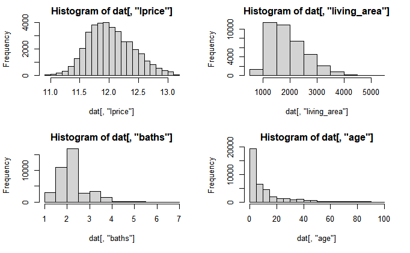

```r
hist(dat[,"baths"])
hist(dat[,"age"])
```

```r
intercept<-rep(1,length(lprice))
x<-as.matrix(cbind(intercept,living_area,baths,age,fireplace,garage_area,condA,condB,condC))
y<-lprice

ols_summary<- function(x, y){
  beta <- solve(t(x)%*%x)%*%(t(x)%*%y)
  res<-y-x%*%beta
  s2hat<-as.numeric((t(res)%*%res)/(length(res)-dim(x)[2]))
  cov.mat<-s2hat[1]*solve(t(x)%*%x)
  std.err<-sqrt(diag(cov.mat))
  tval<-beta/std.err
  names(tval)="tval"
  pval<-2*pt(-abs(tval),length(res)-dim(x)[2])
  summ.mod<-data.frame(cbind(beta,std.err,tval,pval))
  names(summ.mod)<-c("Estimates","Stdard_err","Critical t-value","p-value")
  return(summ.mod)
}

result<- ols_summary(x, y)
result
```

|  | Estimates | Stdard_err | Critical t-value | p-value |
| --- | --- | --- | --- | --- |
| intercept | 1.065079e+01 | 1.762170e-02 | 604.413217 | 0.000000e+00 |
| living_area | 3.730434e-04 | 1.886370e-06 | 197.757238 | 0.000000e+00 |
| baths | 7.346504e-02 | 1.685580e-03 | 43.584440 | 0.000000e+00 |
| age | 2.524081e-03 | 7.454306e-05 | 33.860706 | 1.036325e-247 |
| fireplace | 9.592745e-02 | 3.034495e-03 | 31.612323 | 1.413904e-216 |
| garage_area | 2.984871e-04 | 4.954906e-06 | 60.240715 | 0.000000e+00 |
| condA | 5.462330e-01 | 1.735664e-02 | 31.471120 | 1.092016e-214 |
| condB | 2.663553e-01 | 1.715287e-02 | 15.528320 | 3.250374e-54 |
| condC | 1.160854e-01 | 1.781213e-02 | 6.517209 | 7.250344e-11 |

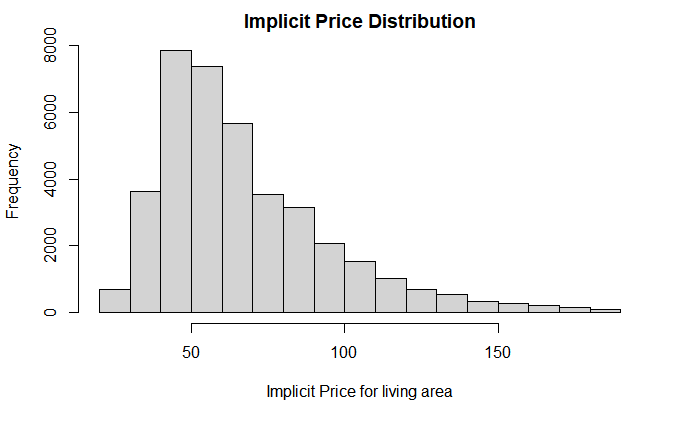

```r
imp_pr<-result$Estimates[2]*price
options(repr.plot.width=4,repr.plot.height=4)
hist(imp_pr,main="Implicit Price Distribution",xlab="Implicit Price for living area")
```

We can observe from the table above that all the independent variables has a positive effect on log-price and independent variables included in the model are highly statistically significant. However, the effects are small and that raises the question whether these are economically significant or not. The distribution of implicit price suggests that households who are pricing between 40 to 70 have the highest frequency.

```r
lakedist<- ifelse(lakedist<=1, 1, lakedist)

log.lakedist<- log(lakedist)

x1<-as.matrix(cbind(intercept,living_area,baths,age,fireplace,garage_area,condA,condB,condC,lakedist,dat["log.lakedist"]))
```

[output not shown]

Here, first we replaced the value of all the values of lakedist less than or equal 1 with 1. From the table we can see that the “Lakedist” is highly significant and log-lakedist is not significant at 5% lavel of significance. Therefore, the functional form of distance doesn’t seem to be important. For our specification the marginal WTP:
$$\frac{\partial Price_i}{\partial distance_i} = \beta_9 Price_i + \beta_{10} \frac{Price_i}{distance_i}$$

```r
x2<-as.matrix(cbind(intercept,living_area,baths,age,fireplace,garage_area,lakedist,log.lakedist))
y<-lprice

result2<- ols_summary(x2, y)
result2
```

|  | Estimates | Stdard_err | Critical t-value | p-value |
| --- | --- | --- | --- | --- |
| intercept | 10.9171767410 | 6.713799e-03 | 1626.0804781 | 0.000000e+00 |
| living_area | 0.0003784248 | 2.022721e-06 | 187.0869643 | 0.000000e+00 |
| baths | 0.0739863042 | 1.818053e-03 | 40.6953574 | 0.000000e+00 |
| age | 0.0039820489 | 7.108383e-05 | 56.0190556 | 0.000000e+00 |
| fireplace | 0.1062300557 | 3.241919e-03 | 32.7676429 | 2.535478e-232 |
| garage_area | 0.0002943397 | 5.318510e-06 | 55.3425087 | 0.000000e+00 |
| lakedist | -0.0017874287 | 1.755953e-04 | -10.1792490 | 2.633418e-24 |
| lakedist.1 | 0.0023774703 | 2.630992e-03 | 0.9036401 | 3.661919e-01 |

```r
imp_pr2<-mean(result2$Estimates[07]*price)+mean(result2$Estimates[08]*(price/lakedist))
print(paste0("Marginal WTP for lake access= ",imp_pr2))
```

```
[1] "Marginal WTP for lake access= -272.302060797607"
```

```r
x3<-as.matrix(cbind(intercept,living_area,baths,age,fireplace,garage_area,condA,condB,condC,lakedist,
                    log.lakedist,median_commute))
y<-lprice

result3<- ols_summary(x3, y)
result3
```

|  | Estimates | Stdard_err | Critical t-value | p-value |
| --- | --- | --- | --- | --- |
| intercept | 10.6184270640 | 1.815587e-02 | 584.848200 | 0.000000e+00 |
| living_area | 0.0003697852 | 1.859511e-06 | 198.861558 | 0.000000e+00 |
| baths | 0.0697200931 | 1.669313e-03 | 41.765750 | 0.000000e+00 |
| age | 0.0014252077 | 7.986267e-05 | 17.845730 | 6.000107e-71 |
| fireplace | 0.0955918472 | 2.982533e-03 | 32.050556 | 1.740865e-222 |
| garage_area | 0.0003083265 | 4.881196e-06 | 63.166167 | 0.000000e+00 |
| condA | 0.4925413333 | 1.713791e-02 | 28.739874 | 9.340238e-180 |
| condB | 0.2398514462 | 1.687404e-02 | 14.214226 | 9.743039e-46 |
| condC | 0.1104432860 | 1.750747e-02 | 6.308352 | 2.850571e-10 |
| lakedist | -0.0008053094 | 1.628693e-04 | -4.944515 | 7.665195e-07 |

[output cut: 2 more lines]

```r
imp_pr3<-mean(result3$Estimates[10]*price)+mean(result3$Estimates[11]*(price/lakedist))
print(paste0("Implicit price for lake access= ",imp_pr3))
```

```
[1] "Implicit price for lake access= -225.203875385696"
```

Adding the median_commute variable into the model, the implicit price increases which is surprising as adding more variables into the model could’ve decreased the weight it puts on the determination of price.

```r
x4<-as.matrix(cbind(intercept,living_area,baths,age,fireplace,garage_area,condA,condB,condC,lakedist,log.lakedist,
                    median_commute,zone1,zone2,zone3,zone4,zone5,zone6,zone7,zone8,zone9,zone10,zone11,zone12,zone13,
                    zone14,zone15,zone16,zone17,zone18))
y<-lprice

result4<- ols_summary(x4, y)
result4
```

|  | Estimates | Stdard_err | Critical t-value | p-value |
| --- | --- | --- | --- | --- |
| intercept | 10.8530680316 | 1.695021e-02 | 640.2911914 | 0.000000e+00 |
| living_area | 0.0003471583 | 1.721801e-06 | 201.6251104 | 0.000000e+00 |
| baths | 0.0626320260 | 1.524372e-03 | 41.0871133 | 0.000000e+00 |
| age | -0.0003410053 | 7.694793e-05 | -4.4316364 | 9.377665e-06 |
| fireplace | 0.0605583287 | 2.720061e-03 | 22.2635902 | 4.030293e-109 |
| garage_area | 0.0002770006 | 4.449123e-06 | 62.2595899 | 0.000000e+00 |
| condA | 0.3249225978 | 1.559455e-02 | 20.8356498 | 6.907293e-96 |
| condB | 0.1796831430 | 1.514006e-02 | 11.8680609 | 1.973951e-32 |
| condC | 0.0911120370 | 1.568567e-02 | 5.8086168 | 6.348196e-09 |
| lakedist | -0.0009250175 | 1.613781e-04 | -5.7319878 | 9.999488e-09 |

[output cut: 20 more lines]

```r
imp_pr4<-mean(result4$Estimates[10]*price)+mean(result4$Estimates[11]*(price/lakedist))
print(paste0("Implicit price for lake access= ",imp_pr4))
```

```
[1] "Implicit price for lake access= -318.003404896892"
```

Adding spatial fixed effects into the model decreases the implicit price for lake access to -318. This is because, as the spatial effects comes into terms, the implicit price for distance from lake gets less weight for determinig the price.

```r
tr_dist<-c()
for (i in 1:length(y)){
  tr_dist[i]<-max(1-(lakedist[i]/10)^0.5,0)}
x5<-as.matrix(cbind(intercept,living_area,baths,age,fireplace,garage_area,condA,condB,condC,lakedist,tr_dist,median_commute,
                    zone1,zone2,zone3,zone4,zone5,zone6,zone7,zone8,zone9,zone10,zone11,zone12,zone13,
                    zone14,zone15,zone16,zone17,zone18))
y<-lprice

result5<- ols_summary(x5, y)
result5
```

|  | Estimates | Stdard_err | Critical t-value | p-value |
| --- | --- | --- | --- | --- |
| intercept | 10.8358151957 | 1.659372e-02 | 653.00718106 | 0.000000e+00 |
| living_area | 0.0003470991 | 1.721298e-06 | 201.64957756 | 0.000000e+00 |
| baths | 0.0625642862 | 1.523126e-03 | 41.07624145 | 0.000000e+00 |
| age | -0.0003420749 | 7.693330e-05 | -4.44638298 | 8.757032e-06 |
| fireplace | 0.0606599754 | 2.719690e-03 | 22.30400385 | 1.653460e-109 |
| garage_area | 0.0002767109 | 4.449269e-06 | 62.19243737 | 0.000000e+00 |
| condA | 0.3251114893 | 1.559239e-02 | 20.85065792 | 5.065823e-96 |
| condB | 0.1797490673 | 1.513781e-02 | 11.87417527 | 1.835302e-32 |
| condC | 0.0910854309 | 1.568344e-02 | 5.80774569 | 6.381275e-09 |
| lakedist | -0.0011468380 | 9.477545e-05 | -12.10058113 | 1.205912e-33 |

[output cut: 20 more lines]

```r
imp_p5<-c()
for (i in 1:length(y)){
  if (tr_dist[i]==0)imp_p5[i]=price[i]*result5$Estimates[10]
  else imp_p5[i]=price[i]*result5$Estimates[10]-((price[i]*result5$Estimates[10])/(2*sqrt(10)*sqrt(lakedist[i])))
}
imp_pr5<-mean(imp_p5)
print(paste0("Implicit price for lake access= ",imp_pr5))
```

```
[1] "Implicit price for lake access= -201.660403319369"
```

However, the non-linear transformation actually tries to rectify the intensity of spatial effect in determinig the price. It shows that although the implicit price of distance from lake decreases when we add spatial effects, the intensity of that decline is a lot smaller in the case of non-linear transformation than the case of log-transformation.